# Matplotlib

Please visit this first: https://matplotlib.org/gallery.html#scales

```python
import matplotlib.pyplot as plt
```

# BASIC PLOT

```python
import numpy as np

x = np.arange(0, 10, 0.2) # evenly sampled time at 0.2 s intervals
x
```

```
array([0. , 0.2, 0.4, 0.6, 0.8, 1. , 1.2, 1.4, 1.6, 1.8, 2. , 2.2, 2.4,
       2.6, 2.8, 3. , 3.2, 3.4, 3.6, 3.8, 4. , 4.2, 4.4, 4.6, 4.8, 5. ,
       5.2, 5.4, 5.6, 5.8, 6. , 6.2, 6.4, 6.6, 6.8, 7. , 7.2, 7.4, 7.6,
       7.8, 8. , 8.2, 8.4, 8.6, 8.8, 9. , 9.2, 9.4, 9.6, 9.8])
```

```python
y = np.sin(x)
```

```python
y
```

```
array([ 0.        ,  0.19866933,  0.38941834,  0.56464247,  0.71735609,
        0.84147098,  0.93203909,  0.98544973,  0.9995736 ,  0.97384763,
        0.90929743,  0.8084964 ,  0.67546318,  0.51550137,  0.33498815,
        0.14112001, -0.05837414, -0.2555411 , -0.44252044, -0.61185789,
       -0.7568025 , -0.87157577, -0.95160207, -0.993691  , -0.99616461,
       -0.95892427, -0.88345466, -0.77276449, -0.63126664, -0.46460218,
       -0.2794155 , -0.0830894 ,  0.1165492 ,  0.31154136,  0.49411335,
        0.6569866 ,  0.79366786,  0.8987081 ,  0.96791967,  0.99854335,
        0.98935825,  0.94073056,  0.85459891,  0.7343971 ,  0.58491719,
        0.41211849,  0.22288991,  0.02477543, -0.17432678, -0.36647913])
```

```
Text(0.5,1,'My first plotting exercise!')
```

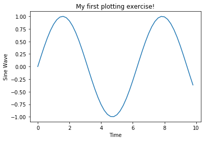

```python
plt.plot(x, y)
# plt.axis([0, 10, 0, 1])

plt.xlabel('Time')
plt.ylabel('Sine Wave')
plt.title('My first plotting exercise!')
```

```python
x
```

```
array([0. , 0.2, 0.4, 0.6, 0.8, 1. , 1.2, 1.4, 1.6, 1.8, 2. , 2.2, 2.4,
       2.6, 2.8, 3. , 3.2, 3.4, 3.6, 3.8, 4. , 4.2, 4.4, 4.6, 4.8, 5. ,
       5.2, 5.4, 5.6, 5.8, 6. , 6.2, 6.4, 6.6, 6.8, 7. , 7.2, 7.4, 7.6,
       7.8, 8. , 8.2, 8.4, 8.6, 8.8, 9. , 9.2, 9.4, 9.6, 9.8])
```

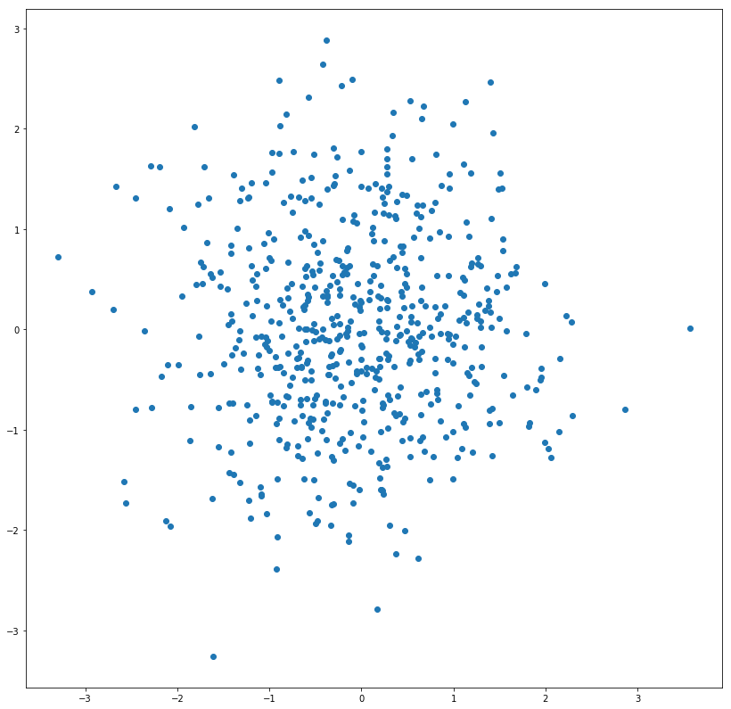

```python
import random

fig = plt.figure(figsize=(14,14))

X = np.random.randn(600)
Y = np.random.randn(600)

plt.scatter(X,Y)
```

# MULTIPLE PLOTS ON SAME FIGURE/LINE FORMATTING

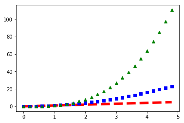

```python
import numpy as np
import matplotlib.pyplot as plt

t = np.arange(0., 5., 0.2) # evenly sampled time at 0.2 s intervals

# red dashes, blue squares and green triangles
plt.plot(t, t, 'r--', t, t**2, 'bs', t, t**3, 'g^', linewidth=5.0)
```

# SUBPLOTS

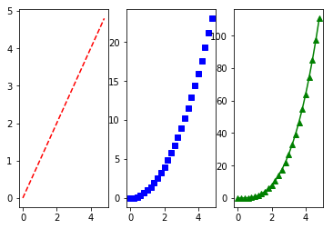

```python
plt.subplot(1, 3, 1)
plt.plot(t, t, 'r--');

plt.subplot(1, 3, 2)
plt.plot(t, t**2, 'bs')

plt.subplot(1, 3, 3)
plt.plot(t, t**3, 'g^-');
```

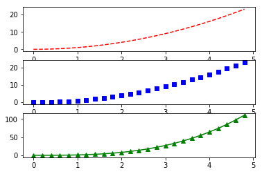

```python
plt.subplot(3, 1, 1)
plt.plot(t, t**2, 'r--')

plt.subplot(3, 1, 2)
plt.plot(t, t**2, 'bs')

plt.subplot(3, 1, 3)
plt.plot(t, t**3, 'g^-');
```

# MATPLOTLIB WITH OBJECT ORIENTED PROGRAMMING

- matplotlib creates a Figure instance, which is an object describing the plot window and its properties, and containing lists of all its elements
- matplotlib creates an Axes element within the figure. An axes can be thought of as a plotting window, where data can be arranged by x and y coordinates.
- add_axes(rectangle), where rectangle is a list [x0, y0, width, height] denoting the lower left point of the new axes in figure coodinates (x0,y0) and its width and height.

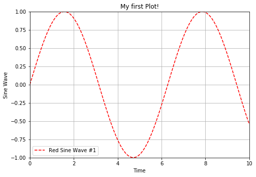

```python
fig  = plt.figure()  # a new figure window
axes = fig.add_axes([0, 0, 1, 1])  # Add new axes

x = np.linspace(0, 10, 100)
y = np.sin(x)
axes.plot(x, y, 'r--', label = "Red Sine Wave #1")
axes.set_xlabel('Time')          # X-label
axes.set_ylabel('Sine Wave')     # y-label
axes.set_title('My first Plot!') # Add a title
axes.legend()                    # Legend
axes.set_ylim([-1, 1])        # set x and y limits
axes.set_xlim([0, 10])
axes.grid()
```

```python
x
```

```
array([ 0.        ,  0.1010101 ,  0.2020202 ,  0.3030303 ,  0.4040404 ,
        0.50505051,  0.60606061,  0.70707071,  0.80808081,  0.90909091,
        1.01010101,  1.11111111,  1.21212121,  1.31313131,  1.41414141,
        1.51515152,  1.61616162,  1.71717172,  1.81818182,  1.91919192,
        2.02020202,  2.12121212,  2.22222222,  2.32323232,  2.42424242,
        2.52525253,  2.62626263,  2.72727273,  2.82828283,  2.92929293,
        3.03030303,  3.13131313,  3.23232323,  3.33333333,  3.43434343,
        3.53535354,  3.63636364,  3.73737374,  3.83838384,  3.93939394,
        4.04040404,  4.14141414,  4.24242424,  4.34343434,  4.44444444,
        4.54545455,  4.64646465,  4.74747475,  4.84848485,  4.94949495,
        5.05050505,  5.15151515,  5.25252525,  5.35353535,  5.45454545,
        5.55555556,  5.65656566,  5.75757576,  5.85858586,  5.95959596,
        6.06060606,  6.16161616,  6.26262626,  6.36363636,  6.46464646,
        6.56565657,  6.66666667,  6.76767677,  6.86868687,  6.96969697,
        7.07070707,  7.17171717,  7.27272727,  7.37373737,  7.47474747,
        7.57575758,  7.67676768,  7.77777778,  7.87878788,  7.97979798,
        8.08080808,  8.18181818,  8.28282828,  8.38383838,  8.48484848,
        8.58585859,  8.68686869,  8.78787879,  8.88888889,  8.98989899,
        9.09090909,  9.19191919,  9.29292929,  9.39393939,  9.49494949,
        9.5959596 ,  9.6969697 ,  9.7979798 ,  9.8989899 , 10.        ])
```

```python
y
```

```
array([ 0.        ,  0.10083842,  0.20064886,  0.2984138 ,  0.39313661,
        0.48385164,  0.56963411,  0.64960951,  0.72296256,  0.78894546,
        0.84688556,  0.8961922 ,  0.93636273,  0.96698762,  0.98775469,
        0.99845223,  0.99897117,  0.98930624,  0.96955595,  0.93992165,
        0.90070545,  0.85230712,  0.79522006,  0.73002623,  0.65739025,
        0.57805259,  0.49282204,  0.40256749,  0.30820902,  0.21070855,
        0.11106004,  0.01027934, -0.09060615, -0.19056796, -0.28858706,
       -0.38366419, -0.47483011, -0.56115544, -0.64176014, -0.7158225 ,
       -0.7825875 , -0.84137452, -0.89158426, -0.93270486, -0.96431712,
       -0.98609877, -0.99782778, -0.99938456, -0.99075324, -0.97202182,
       -0.94338126, -0.90512352, -0.85763861, -0.80141062, -0.73701276,
       -0.66510151, -0.58640998, -0.50174037, -0.41195583, -0.31797166,
       -0.22074597, -0.12126992, -0.0205576 ,  0.0803643 ,  0.18046693,
        0.27872982,  0.37415123,  0.46575841,  0.55261747,  0.63384295,
        0.7086068 ,  0.77614685,  0.83577457,  0.8868821 ,  0.92894843,
        0.96154471,  0.98433866,  0.99709789,  0.99969234,  0.99209556,
        0.97438499,  0.94674118,  0.90944594,  0.86287948,  0.8075165 ,
        0.74392141,  0.6727425 ,  0.59470541,  0.51060568,  0.42130064,
        0.32770071,  0.23076008,  0.13146699,  0.03083368, -0.07011396,
       -0.17034683, -0.26884313, -0.36459873, -0.45663749, -0.54402111])
```

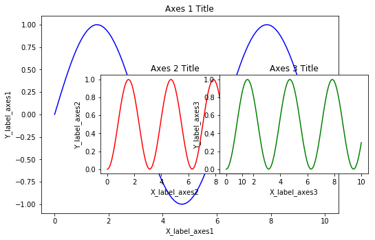

```python
# Creates a new figure
fig = plt.figure()

axes1 = fig.add_axes([0, 0, 1, 1]) # main axes
axes2 = fig.add_axes([0.2, 0.2, 0.5, 0.5]) # inset axes
axes3 = fig.add_axes([0.6, 0.2, 0.5, 0.5]) # inset axes

# Larger Figure Axes 1
axes1.plot(x, y, 'b')
axes1.set_xlabel('X_label_axes1')
axes1.set_ylabel('Y_label_axes1')
axes1.set_title('Axes 1 Title')

# Insert Figure Axes 2
axes2.plot(x, y**2, 'r')
axes2.set_xlabel('X_label_axes2')
axes2.set_ylabel('Y_label_axes2')
axes2.set_title('Axes 2 Title');

# Insert Figure Axes 3
axes3.plot(x, y**2, 'g')
axes3.set_xlabel('X_label_axes3')
axes3.set_ylabel('Y_label_axes3')
axes3.set_title('Axes 3 Title');
```

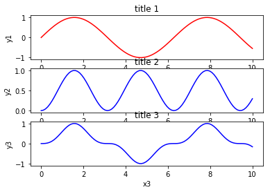

```python
fig, axes = plt.subplots(nrows = 3, ncols = 1)
axes

# Use axes object to add elements to plot
axes[0].plot(x, y, 'r')
axes[0].set_xlabel('x1')
axes[0].set_ylabel('y1')
axes[0].set_title('title 1');

axes[1].plot(x, y**2, 'b')
axes[1].set_xlabel('x2')
axes[1].set_ylabel('y2')
axes[1].set_title('title 2');

axes[2].plot(x, y**3, 'b')
axes[2].set_xlabel('x3')
axes[2].set_ylabel('y3')
axes[2].set_title('title 3');
```

# ADJUST FIGURE SIZE, SPACING, COLOR

- plt.subplots_adjust(left=None, bottom=None, right=None, top=None, wspace=None, hspace=0.4)
  - left: left side of the subplots of the figure
  - right: right side of the subplots of the figure
  - bottom: bottom of the subplots of the figure
  - top: top of the subplots of the figure
  - wspace: amount of width reserved for space between subplots, expressed as a fraction of the average axis width
  - hspace: amount of height reserved for space between subplots, expressed as a fraction of the average axis height

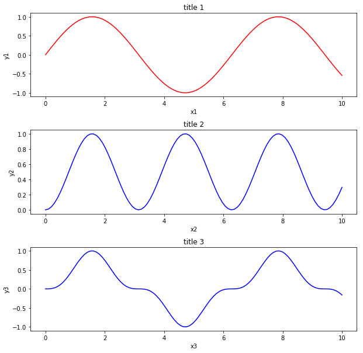

```python
fig, axes = plt.subplots(nrows = 3, ncols = 1, figsize=(10,10))
axes

# Use axes object to add elements to plot
axes[0].plot(x, y, 'r')
axes[0].set_xlabel('x1')
axes[0].set_ylabel('y1')
axes[0].set_title('title 1');

axes[1].plot(x, y**2, 'b')
axes[1].set_xlabel('x2')
axes[1].set_ylabel('y2')
axes[1].set_title('title 2');

axes[2].plot(x, y**3, 'b')
axes[2].set_xlabel('x3')
axes[2].set_ylabel('y3')
axes[2].set_title('title 3');


plt.subplots_adjust(left=None, bottom=None, right=None, top=None, wspace=None, hspace=0.4)
```

# MARKERS AND LINE STYLES

- plt.plot(x, y, linestyle='--', marker='o', color='b')
- plt.plot(x, y, '--bo')

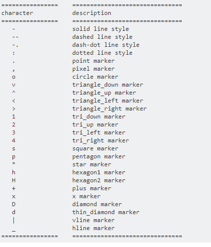

Reference: https://stackoverflow.com/questions/8409095/matplotlib-set-markers-for-individual-points-on-a-line

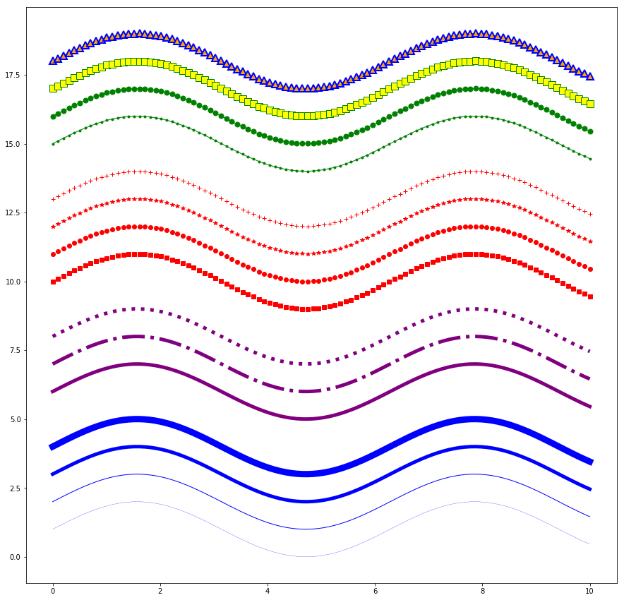

```python
fig, axes = plt.subplots(figsize=(15,15))

t = np.linspace(0, 10, 100)

# Lin width options
axes.plot(t, np.sin(t) + 1, color="blue", lw = 0.25)
axes.plot(t, np.sin(t) + 2, color="blue", lw = 1)
axes.plot(t, np.sin(t) + 3, color="blue", lw = 5)
axes.plot(t, np.sin(t) + 4, color="blue", lw = 9)

# Line Style options
axes.plot(t, np.sin(t) + 6, color="purple", lw = 5, ls ='-')
axes.plot(t, np.sin(t) + 7, color="purple", lw = 5, ls ='-.')
axes.plot(t, np.sin(t) + 8, color="purple", lw = 5, ls =':')


# Markers options
axes.plot(t, np.sin(t) + 10, color="red", lw = 0.1, ls='-', marker='s')
axes.plot(t, np.sin(t) + 11, color="red", lw = 0.1, ls='-', marker='o')
axes.plot(t, np.sin(t) + 12, color="red", lw = 0.1, ls='-', marker='*')
axes.plot(t, np.sin(t) + 13, color="red", lw = 0.1, ls='-', marker='+')


# marker size and color
axes.plot(t, np.sin(t) + 15, color="green", lw=1, ls='-', marker='o', markersize=3)
axes.plot(t, np.sin(t) + 16, color="green", lw=1, ls='-', marker='o', markersize=7)
axes.plot(t, np.sin(t) + 17, color="green", lw=1, ls='-', marker='s', markersize=10, markerfacecolor="yellow")
axes.plot(t, np.sin(t) + 18, color="green", lw=1, ls='-', marker='^', markersize=10, markerfacecolor="orange", markeredgewidth=2, markeredgecolor="blue");
```

# HISTOGRAMS AND BOXPLOTS

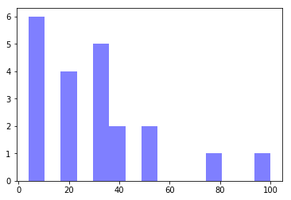

```python
# import matplotlib.mlab as mlab

x = [21, 22, 23, 4, 5, 6, 77, 8, 9, 10, 31, 32, 33, 34, 35, 36, 37, 18, 49, 50, 100]

num_bins = 15

n, bins, patches = plt.hist(x, num_bins, facecolor='blue', alpha = 0.5)
```

```
Text(0.5,1,'Histogram: $\\mu=20$, $\\sigma=3$')
```

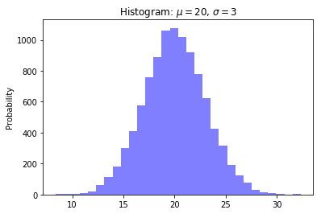

```python
mu = 20 # mean of distribution
sigma = 3 # standard deviation of distribution
x = mu + sigma * np.random.randn(10000)

num_bins = 30

n, bins, patches = plt.hist(x, num_bins, facecolor='blue', alpha=0.5)

plt.ylabel('Probability')
plt.title(r'Histogram: $\mu=20$, $\sigma=3$')
```

[figure not shown]

Reference: https://stackoverflow.com/questions/17725927/boxplots-in-matplotlib-markers-and-outliers

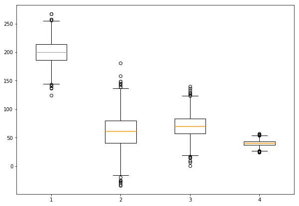

```python
# numpy.random.normal() takes three arguments: mean, standard deviation of the normal distribution, and number of values desired.

np.random.seed(20)

data_1 = np.random.normal(200, 20, 2000)
data_2 = np.random.normal(60, 30, 2000)
data_3 = np.random.normal(70, 20, 2000)
data_4 = np.random.normal(40, 5, 2000)

data_all = [data_1, data_2, data_3, data_4]


fig = plt.figure(figsize=(10, 7))
ax = fig.add_subplot(111)
bp = ax.boxplot(data_all)
```

# 3-D PLOTTING

```
Text(0.5,0,'Z Label')
```

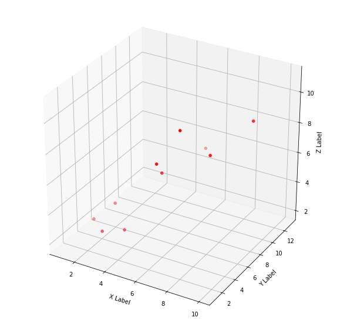

```python
from mpl_toolkits.mplot3d import Axes3D

fig = plt.figure(figsize=(10,10))
ax = fig.add_subplot(111, projection='3d')

x =[1 , 2, 3, 4, 5, 6, 7, 8, 9, 10]
y =[5, 6, 2, 3, 13, 4, 1, 2, 4, 8]
z =[2, 3, 3, 3, 5, 7, 9, 11, 9, 10]

ax.scatter(x, y, z, c='r', marker='o')

ax.set_xlabel('X Label')
ax.set_ylabel('Y Label')
ax.set_zlabel('Z Label')
```

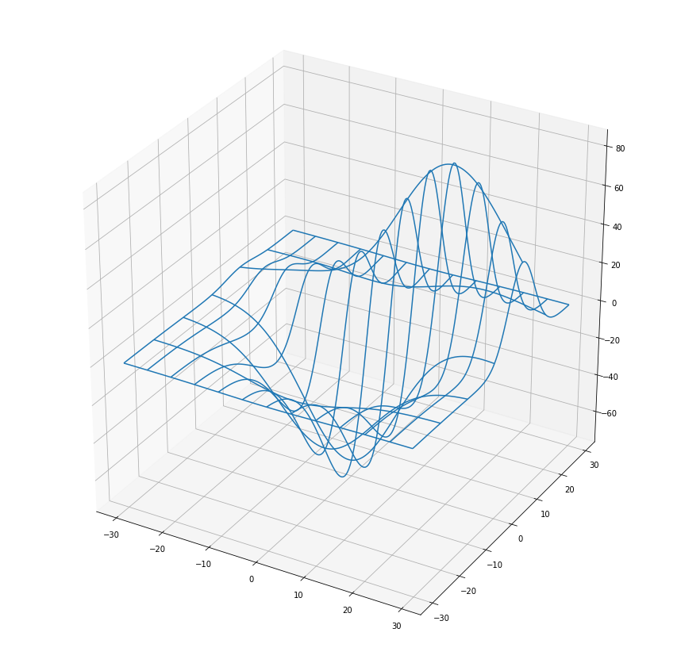

```python
from mpl_toolkits.mplot3d import axes3d
import matplotlib.pyplot as plt

fig = plt.figure(figsize=(15,15))
ax = fig.add_subplot(111, projection='3d')

# Grab some test data.
X, Y, Z = axes3d.get_test_data(0.05)

# Plot a basic wireframe.
ax.plot_wireframe(X, Y, Z, rstride=20, cstride=10)
```

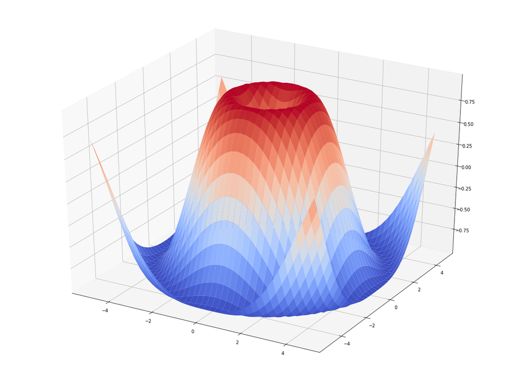

```python
from mpl_toolkits.mplot3d import Axes3D
from matplotlib import cm

fig = plt.figure(figsize=(20,15))
ax = fig.gca(projection='3d')

X = np.arange(-5, 5, 0.25)
Y = np.arange(-5, 5, 0.25)
X, Y = np.meshgrid(X, Y)
R = np.sqrt(X**2 + Y**2)
Z = np.sin(R)

# Plot the surface.
surf = ax.plot_surface(X, Y, Z, cmap=cm.coolwarm)
```

# PIE PLOTS

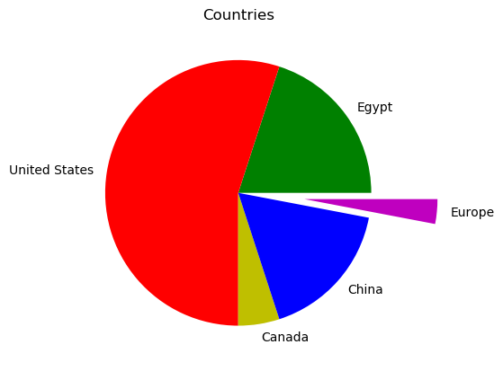

```python
plt.rcdefaults()

values = [20, 55, 5, 17, 3]
colors = ['g', 'r', 'y', 'b', 'm']
explode = [0, 0, 0, 0, 0.5]
labels = ['Egypt', 'United States', 'Canada', 'China', 'Europe']
plt.pie(values, colors= colors, labels=labels, explode = explode)
plt.title('Countries')
plt.show()
```